# Goodness of Fit Test

coop711

2015년 3월 14일

## Matching Problems

- 매칭 문제에서 관찰한 값들을 data frame 으로 저장.

```r
options(digits=3)
n.matching<-c(0,1,2,4)
o.matching<-c(22,12,15,1)
p.matching<-c(9,8,6,1)/24
matching<-data.frame(n.matching, o.matching, p.matching)
matching
```

```
##   n.matching o.matching p.matching
## 1          0         22     0.3750
## 2          1         12     0.3333
## 3          2         15     0.2500
## 4          4          1     0.0417
```

- 표본평균을 계산하여 $1\pm 1/\sqrt{50}$ 에 들어가는 지 확인.

```r
mean.matching<-sum(n.matching*o.matching/sum(o.matching))
mean.matching
```

```
## [1] 0.92
```

- p.matching 으로 계산한 확률모델에 부합하는지 적합도 검정 수행. 각종 검정통계량 확인. warning() 이 나온 이유가 무엇인지 함께 산출된 통계값들을 근거로 파악.

```r
chisq.test.matching<-chisq.test(x=o.matching,p=p.matching)
```

```
## Warning in chisq.test(x = o.matching, p = p.matching): Chi-squared
## approximation may be incorrect
```

```r
chisq.test.matching
```

```
##
##  Chi-squared test for given probabilities
##
## data:  o.matching
## X-squared = 2.93, df = 3, p-value = 0.402
```

```r
chisq.test.matching$statistic
```

```
## X-squared
##      2.93
```

```r
chisq.test.matching$parameter
```

```
## df
##  3
```

```r
chisq.test.matching$p.value
```

```
## [1] 0.402
```

```r
chisq.test.matching$method
```

```
## [1] "Chi-squared test for given probabilities"
```

```r
chisq.test.matching$data.name
```

```
## [1] "o.matching"
```

```r
chisq.test.matching$observed
```

```
## [1] 22 12 15  1
```

```r
chisq.test.matching$expected
```

```
## [1] 18.75 16.67 12.50  2.08
```

```r
chisq.test.matching$residuals
```

```
## [1]  0.751 -1.143  0.707 -0.751
```

```r
chisq.test.matching$stdres
```

```
## [1]  0.949 -1.400  0.816 -0.767
```

- 검정통계량을 계산하고, p-value를 찾는 과정을 단계별로 살펴보자.

```r
sum(o.matching)
```

```
## [1] 50
```

```r
e.matching<-50*p.matching
e.matching
```

```
## [1] 18.75 16.67 12.50  2.08
```

```r
(o.matching-e.matching)**2/e.matching
```

```
## [1] 0.563 1.307 0.500 0.563
```

```r
sum((o.matching-e.matching)**2/e.matching)
```

```
## [1] 2.93
```

```r
chisq.matching<-sum((o.matching-e.matching)**2/e.matching)
chisq.matching
```

```
## [1] 2.93
```

```r
p.value<-1-pchisq(chisq.matching, df=3)
p.value
```

```
## [1] 0.402
```

- warnings()가 나온 이유는 기대돗수가 5보다 작은 값들이 나왔기 때문이므로 matching이 2와 4인 경우를 합하여 카이제곱 적합도 검증을 다시 수행할 필요. 그 과정은 다음과 같음. 우선 매칭 자료를 하나의 data frame 으로 구성하고 구조 파악. n.matching은 수치로서의 의미도 있으나 적합도 검정에서는 구분의 역할만 하므로 나중에 factor로 재구조화.

```r
matching<-data.frame(n.matching=n.matching, o.matching=o.matching, p.matching=p.matching)
matching
```

```
##   n.matching o.matching p.matching
## 1          0         22     0.3750
## 2          1         12     0.3333
## 3          2         15     0.2500
## 4          4          1     0.0417
```

```r
str(matching)
```

```
## 'data.frame':    4 obs. of  3 variables:
##  $ n.matching: num  0 1 2 4
##  $ o.matching: num  22 12 15 1
##  $ p.matching: num  0.375 0.3333 0.25 0.0417
```

```r
matching.2<-matching
matching.2
```

```
##   n.matching o.matching p.matching
## 1          0         22     0.3750
## 2          1         12     0.3333
## 3          2         15     0.2500
## 4          4          1     0.0417
```

```r
matching.2[5,]<-matching.2[3,]+matching.2[4,]
matching.2
```

```
##   n.matching o.matching p.matching
## 1          0         22     0.3750
## 2          1         12     0.3333
## 3          2         15     0.2500
## 4          4          1     0.0417
## 5          6         16     0.2917
```

```r
matching.2<-matching.2[-(3:4),]
matching.2
```

```
##   n.matching o.matching p.matching
## 1          0         22      0.375
## 2          1         12      0.333
## 5          6         16      0.292
```

```r
matching.2$n.matching<-factor(matching.2$n.matching, levels=c(0,1,6),labels=c("0","1","2 or 4"))
chisq.test(x=matching.2$o.matching,p=matching.2$p.matching)
```

```
##
##  Chi-squared test for given probabilities
##
## data:  matching.2$o.matching
## X-squared = 2.01, df = 2, p-value = 0.3665
```

- 셀병합을 하지 않고 p-value를 구하는 방법은 붓스트랩을 활용하는 것으로 simulate.p.value=T, B=2000 등을 지정하는 것임. 이러한 방식으로 p-value를 구하는 것이 frequentist 관점에 보다 부합함. 이 작업은 반복할 때 마다 값이 달라질 수 밖에 없음. 그럼에도 불구하고 당초 카이제곱 분포로 근사한 값과 거의 같은 값을 얻게 됨에 유의.

```r
chisq.matching.B<-chisq.test(x=o.matching, p=p.matching, simulate.p.value=T, B=2000)
chisq.matching.B
```

```
##
##  Chi-squared test for given probabilities with simulated p-value
##  (based on 2000 replicates)
##
## data:  o.matching
## X-squared = 2.93, df = NA, p-value = 0.4013
```

## Lottery Data의 Uniformity Test

- lottery 자료 읽어들이기. 기초통계 확인.

```r
lottery<-read.table("lottery.txt",header=TRUE)
head(lottery)
```

```
##   lottery.number lottery.payoff
## 1            810            190
## 2            156            120
## 3            140            286
## 4            542            184
## 5            507            384
## 6            972            324
```

```r
attach(lottery)
```

- lottery의 시행과정을 듣고 각 기초통계 값이 이론적으로 기대하는 값과 잘 들어맞는지 판단.

```r
summary(lottery.number)
```

```
##    Min. 1st Qu.  Median    Mean 3rd Qu.    Max.
##       0     230     440     472     734     999
```

```r
sd(lottery.number)
```

```
## [1] 294
```

## One Sample Test

- 당첨번호들이 공평하게 나왔다면 0에서 999사이의 어느 번호나 랜덤하게 나올 수 있으므로 모평균이 $\frac{0+999}{2}=499.5$, 표준편차는 $\sqrt{\frac{(999-0)^2}{12}}\approx288$ 인 모집단에서 254회 복원추출한 표본으로 생각할 수 있음. 모평균 $\mu=499.5$를 t.test로 검정하여보면? (표본의 표준편차는 모집단의 표준편차와 거의 비슷.) 모집단이 정규분포와는 판이하게 다름에도 불구하고 t.test를 수행할 수 있는 배경은?

```r
lottery.t.test<-t.test(lottery.number, mu=499.5)
lottery.t.test$statistic
```

```
##     t
## -1.48
```

```r
lottery.t.test$method
```

```
## [1] "One Sample t-test"
```

- 실제로 t 값을 구하는 과정을 R로 살펴보자.

```r
mean.number<-mean(lottery$lottery.number)
sd.number<-sd(lottery$lottery.number)
lottery.t<-(mean.number-499.5)/(sd.number/sqrt(254))
lottery.t
```

```
## [1] -1.48
```

```r
pt(lottery.t, df=253)*2
```

```
## [1] 0.141
```

```r
pnorm(lottery.t)*2
```

```
## [1] 0.14
```

## 카이제곱 적합도 검정

- lottery.number 의 분포를 살피기 위하여 히스토그램 작성

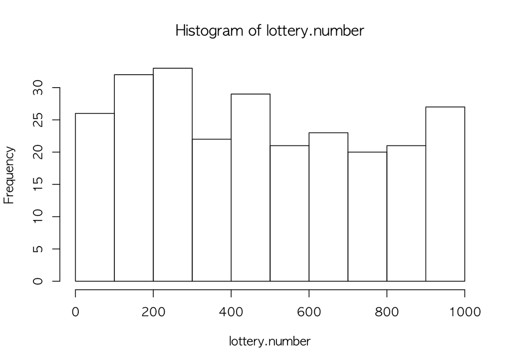

```r
h10<-hist(lottery.number)
```

- 각 계급에 관찰된 당첨번호의 갯수를 파악하기 위하여 h10$counts 출력

```r
h10$counts
```

```
##  [1] 26 32 33 22 29 21 23 20 21 27
```

- 당첨번호의 갯수가 uniform 하게 추출된 것으로 보아도 무방한지 $\chi^2$ 테스트 수행. 왜 다른 argument들을 설정하지 않아도 되는지 help 파일로 확인하고, 이어서 계산되는 값들 중에서 기대돗수 확인.

```r
chisq.test(h10$counts)
```

```
##
##  Chi-squared test for given probabilities
##
## data:  h10$counts
## X-squared = 7.97, df = 9, p-value = 0.5373
```

```r
chisq.test(h10$counts)$expected
```

```
##  [1] 25.4 25.4 25.4 25.4 25.4 25.4 25.4 25.4 25.4 25.4
```

- 계급의 갯수를 바꿔가면서 테스트, breaks로 조정하는 이유에 대하여 생각해 볼 것.

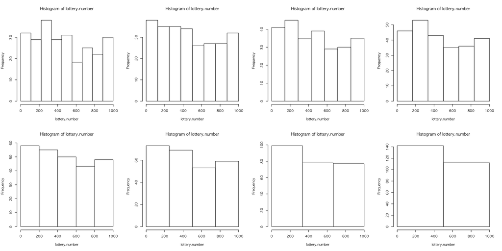

```r
opar<-par(no.readonly=TRUE)
par(mfrow=c(2,4))
h9<-hist(lottery.number, breaks=seq(0,999, by=111))
h8<-hist(lottery.number, breaks=seq(0,1000, by=125))
h7<-hist(lottery.number, breaks=seq(0,1001, by=143))
h6<-hist(lottery.number, breaks=seq(0,1002, by=167))
h5<-hist(lottery.number, breaks=seq(0,1000, by=200))
h4<-hist(lottery.number, breaks=seq(0,1000, by=250))
h3<-hist(lottery.number, breaks=seq(0,999, by=333))
h2<-hist(lottery.number, breaks=seq(0,1000, by=500))
```

- 각각의 count 통계량에 대하여 uniformity 적합도 검정을 하기 위하여 다음 수행. 같은 작업을 sapply()로 수행하면 어떤 결과가 나오는지 비교하시오.

```r
lapply(list(h9$counts, h8$counts, h7$counts, h6$counts, h5$counts, h4$counts, h3$counts, h2$counts), chisq.test)
```

```
## [[1]]
##
##  Chi-squared test for given probabilities
##
## data:  X[[1L]]
## X-squared = 9.76, df = 8, p-value = 0.282
##
##
## [[2]]
##
##  Chi-squared test for given probabilities
##
## data:  X[[2L]]
## X-squared = 4.52, df = 7, p-value = 0.7183
##
##
## [[3]]
##
##  Chi-squared test for given probabilities
##
## data:  X[[3L]]
## X-squared = 5.55, df = 6, p-value = 0.4753
##
##
## [[4]]
##
##  Chi-squared test for given probabilities
##
## data:  X[[4L]]
## X-squared = 5.28, df = 5, p-value = 0.3832
##
##
## [[5]]
##
##  Chi-squared test for given probabilities
##
## data:  X[[5L]]
## X-squared = 2.73, df = 4, p-value = 0.6036
##
##
## [[6]]
##
##  Chi-squared test for given probabilities
##
## data:  X[[6L]]
## X-squared = 3.95, df = 3, p-value = 0.2666
##
##
## [[7]]
##
##  Chi-squared test for given probabilities
##
## data:  X[[7L]]
## X-squared = 3.65, df = 2, p-value = 0.1616
##
##
## [[8]]
##
##  Chi-squared test for given probabilities
##
## data:  X[[8L]]
## X-squared = 3.54, df = 1, p-value = 0.05979
```

- 위의 결과와 아래의 결과를 비교하여 어떤 것이 더 보기에 나은지 비교하시오.

```r
lapply(list(h9=h9$counts, h8=h8$counts, h7=h7$counts, h6=h6$counts, h5=h5$counts, h4=h4$counts, h3=h3$counts, h2=h2$counts), chisq.test)
```

```
## $h9
##
##  Chi-squared test for given probabilities
##
## data:  X[[1L]]
## X-squared = 9.76, df = 8, p-value = 0.282
##
##
## $h8
##
##  Chi-squared test for given probabilities
##
## data:  X[[2L]]
## X-squared = 4.52, df = 7, p-value = 0.7183
##
##
## $h7
##
##  Chi-squared test for given probabilities
##
## data:  X[[3L]]
## X-squared = 5.55, df = 6, p-value = 0.4753
##
##
## $h6
##
##  Chi-squared test for given probabilities
##
## data:  X[[4L]]
## X-squared = 5.28, df = 5, p-value = 0.3832
##
##
## $h5
##
##  Chi-squared test for given probabilities
##
## data:  X[[5L]]
## X-squared = 2.73, df = 4, p-value = 0.6036
##
##
## $h4
##
##  Chi-squared test for given probabilities
##
## data:  X[[6L]]
## X-squared = 3.95, df = 3, p-value = 0.2666
##
##
## $h3
##
##  Chi-squared test for given probabilities
##
## data:  X[[7L]]
## X-squared = 3.65, df = 2, p-value = 0.1616
##
##
## $h2
##
##  Chi-squared test for given probabilities
##
## data:  X[[8L]]
## X-squared = 3.54, df = 1, p-value = 0.05979
```

```r
detach()
```